# Simulate time-dependent head and flow in a semi-infinite aquifer adjacent to open water.

C.H. van Immerzeel

24/4/2025

Simulate time-dependent head and flow in a semi-infinite aquifer adjacent to open water (for example a river), where the boundary condition changes from t = 0 according to a specified course.

The equation used describes one-dimensional flow for a situation with spatially constant kD and S, without recharge (precipitation, evaporation, leakage).

The response to a sequence of stress values (a) may be studied (simulation option).

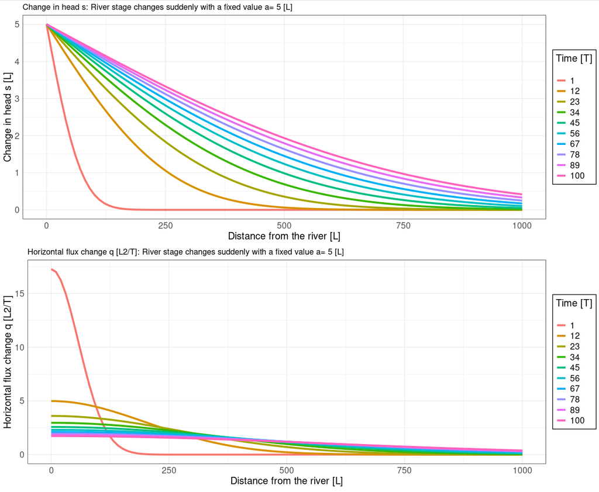

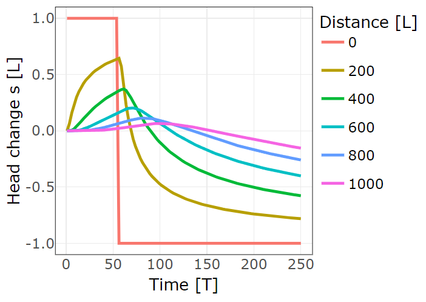

Image

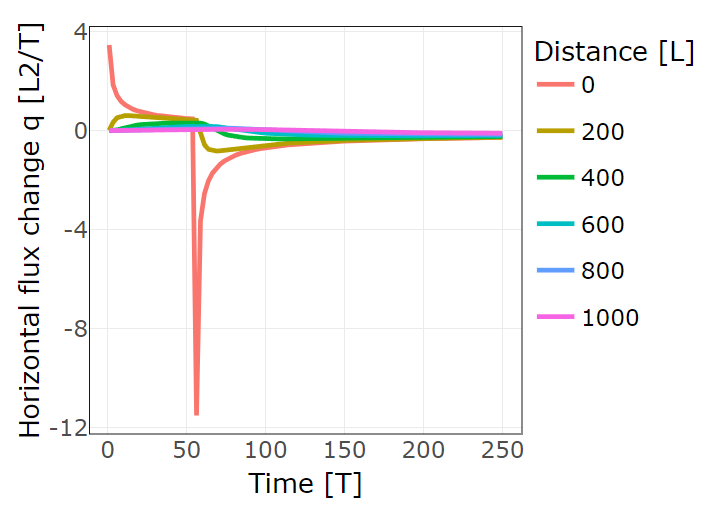

Image

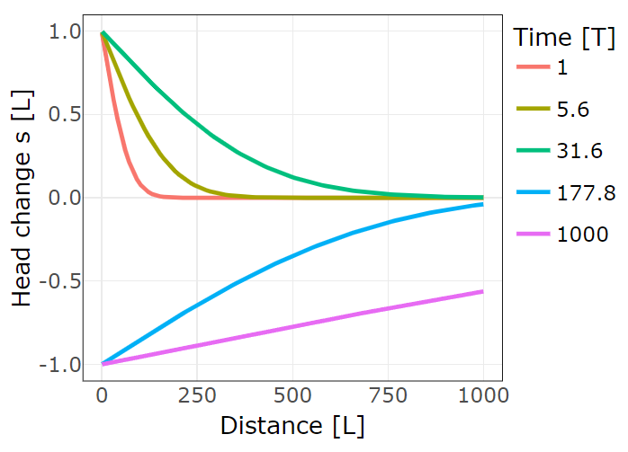

Image

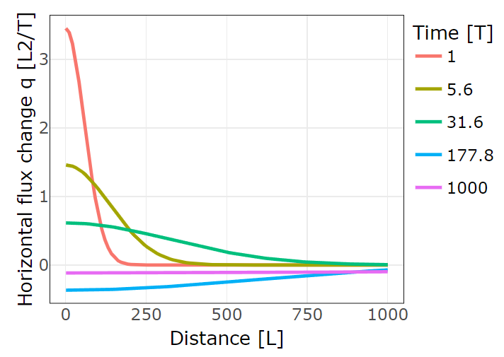

Image

## Link to the app

https://sweco.shinyapps.io/Brug1D/

## Source code

R-source code of the app:

https://github.com/KeesVanImmerzeel/Brug1D

## Simulation

A sequence of stress values (a) may be uploaded. For this purpuse, prepare a spreadsheet with two columns (‘Time’ and ‘a’).

## Numerical stability

Be aware that exotic input values may lead to numerical instability. In that case, no results or plots are presented. Instead, an error message appears.

## References

- Olsthoorn, T.N. (2006). Van Edelman naar Bruggeman. Stromingen 12 (2006) nummer 1, blz. 5-12. https://edepot.wur.nl/13730
- Veling, E.J.M. (2006). Over de erfc-functie in ‘Van Edelman naar Bruggeman’. Stromingen 12 (2006) nummer 2, blz. 56-57. https://www.nhv.nu/wp-content/uploads/2020/06/2006-2_brieven.pdf
- http://www.grondwaterformules.nl/index.php/formules/waterloop/peilverandering

## Van Edelman naar Bruggeman

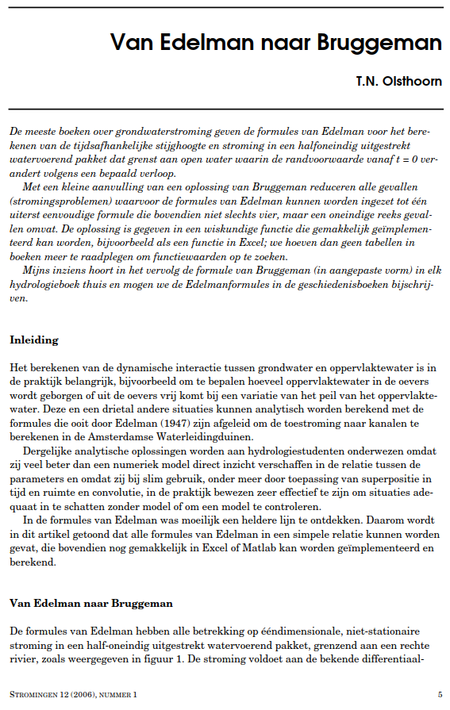

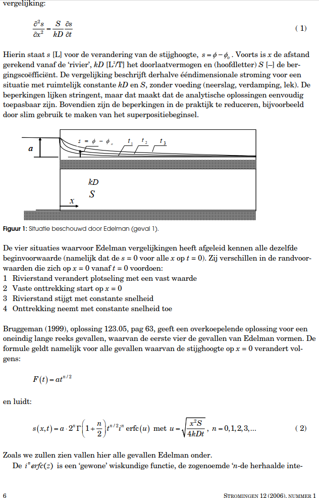

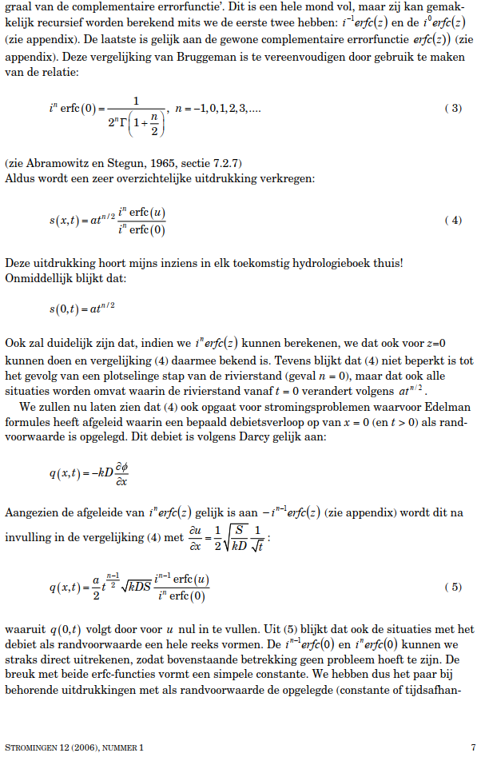

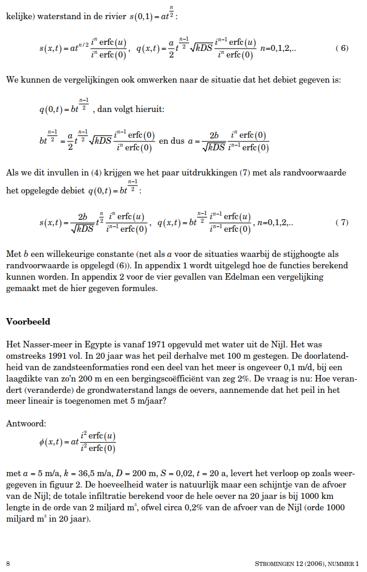

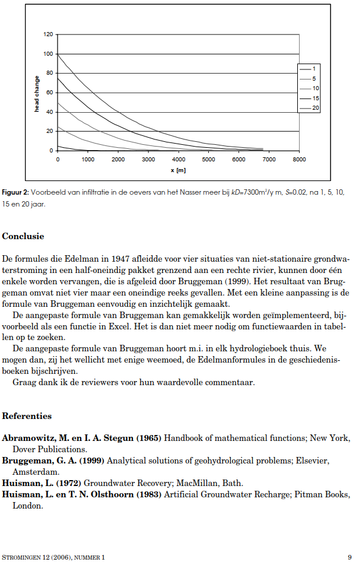

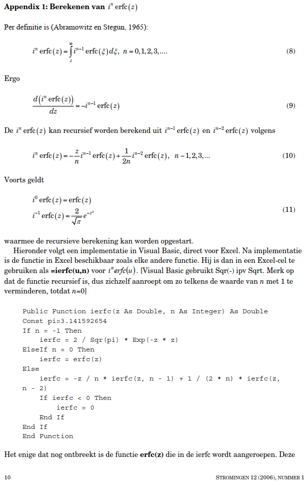

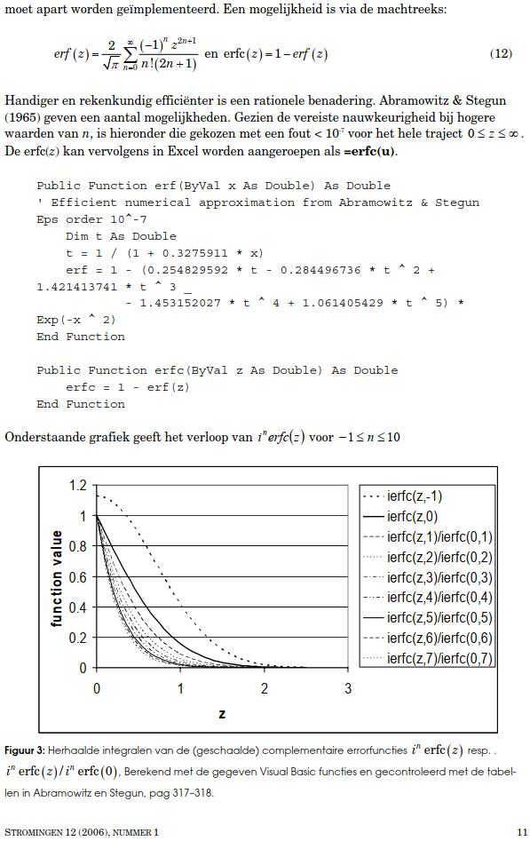

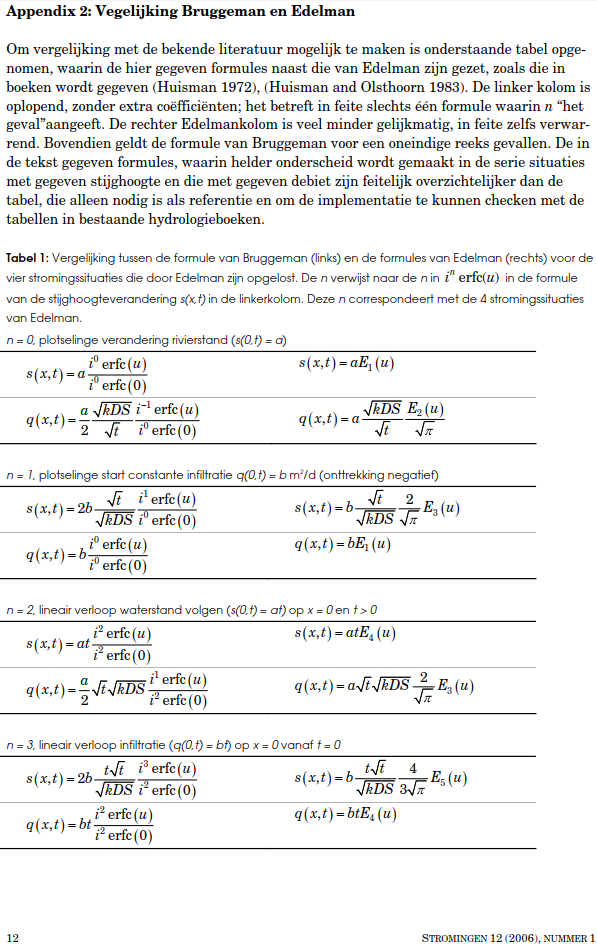